# Personal Finance Analysis using R

Miguel Castillo

03/01/2022

## Introduction

Data is everywhere and we can make good use of it by starting with our personal expenses. The data being used here was created just for educational purposes to explain how the R Script created works. You can always change the data set used with one with your own expenses.

### Libraries

The R script uses these libraries: * Lubridate * tidiverse

## The Data Set

The data set was created as a CSV file using a Spreadsheet application and it consist of 7 columns and 42 rows.

One of the 7 columns is called date_of_purchased, which is then separated into days, months and years for subsequent processing. The month column is then converted to text format for reading easiness.

```r
expenses_dataset <- separate(expenses_dataset, date_of_purchase, into=c('day','month','year'),sep='/')
months_name <- c('Jan', 'Feb', 'Mar', 'Apr', 'May', 'Jun', 'Jul', 'Aug', 'Sep', 'Oct', 'Nov', 'Dec')
expenses_dataset$day <- as.integer(expenses_dataset$day)
expenses_dataset$month <- as.integer(expenses_dataset$month)
expenses_dataset$year <- as.integer(expenses_dataset$year)
expenses_dataset$price <- as.numeric(expenses_dataset$price)
```

This is a preview of the data set.

```r
head(expenses_dataset)
```

```
##   ï..id                 description        brand place_of_purchase
## 1     1                   Breakfast Restaurant A      Restaurant A
## 2     2 Taxi from home to workplace         Uber               N/A
## 3     3         Medical appointment    Clinica A          Clinic A
## 4     4                   Inyection          N/A          Clinic A
## 5     5                 Inyecciones          N/A          Clinic A
## 6     6                     Cookies      Brand A           Store A
##             category day month year  price
## 1 Food and Beverages  19     2 2018 681.00
## 2     Transportation  20     8 2018 110.02
## 3             Health  20     8 2018  50.00
## 4             Health  21     8 2018  20.00
## 5             Health  22     8 2018  30.00
## 6            Dessert  23     8 2018  18.00
```

## Rearreanging method

The data set will be rearranged in to 3 different data sets for specific analysis purposes.

Creating the category_expense data frame. In this way, we can group the expenses by category and getting the total for each category, finally, sorting them in descending order.

```r
category_expense <- expenses_dataset %>%
  group_by(category) %>%
  summarise(total = sum(price)) %>%
  arrange(desc(total))
```

Then, creating the month_expense data frame. In this way, we can group by month and getting the total expense for each month.

```r
month_expense <- expenses_dataset %>%
  group_by(month) %>%
  summarise(total = sum(price))
# Converting months to name for easiness reading
month_expense$month <- months_name[as.integer(month_expense$month)]
# Creating vector of months in numeric value to get the trend line
numeric_months <- match(month_expense$month,month.abb)
```

Finally, Creating the year_expense data frame. In this way, we can group by year and getting the total amount spend per year.

```r
year_expense <- expenses_dataset %>%
  group_by(year) %>%
  summarise(total = sum(price))
```

## Plotting and analyzing

Plotting the category_expense data set Using columns (bars) and ordering in descending total order using reorder() Filling each bar from green to red to visually see in which category did we spent the most.

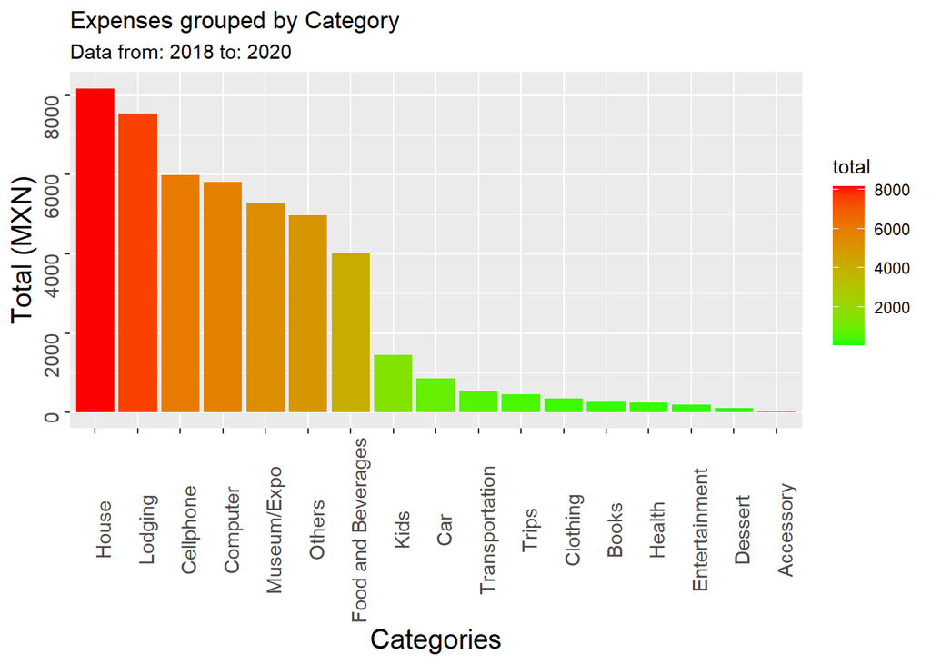

```r
ggplot(category_expense) +
  geom_col(mapping = aes(x=reorder(category, -total), y = total, fill = total)) +
  scale_fill_gradient(low = "green", high = "red", space = 'Lab') +
  theme(axis.text.x = element_text(angle = 90, size = 11), axis.text.y = element_text(angle = 90, size = 11), axis.title.x = element_text(size = 15), axis.title.y = element_text(size = 15)) +
  labs(title = 'Expenses grouped by Category', subtitle = paste0("Data from: ", minyear, " to: ", maxyear), x = "Categories", y = 'Total (MXN)')
```

```r
filter(expenses_dataset, category == "House")
```

```
##   ï..id  description   brand place_of_purchase category day month year   price
## 1    31 Pantry Stuff     N/A           Store A    House   6     7 2020  370.19
## 2    35       Fridge Brand H           Store F    House  26     7 2020 7600.00
## 3    36 Pantry Stuff     N/A           Store A    House   8     8 2020  208.38
```

Then, get the plot from the month_expense data set. Again, using columns (bars) and filling each bar from green to red.

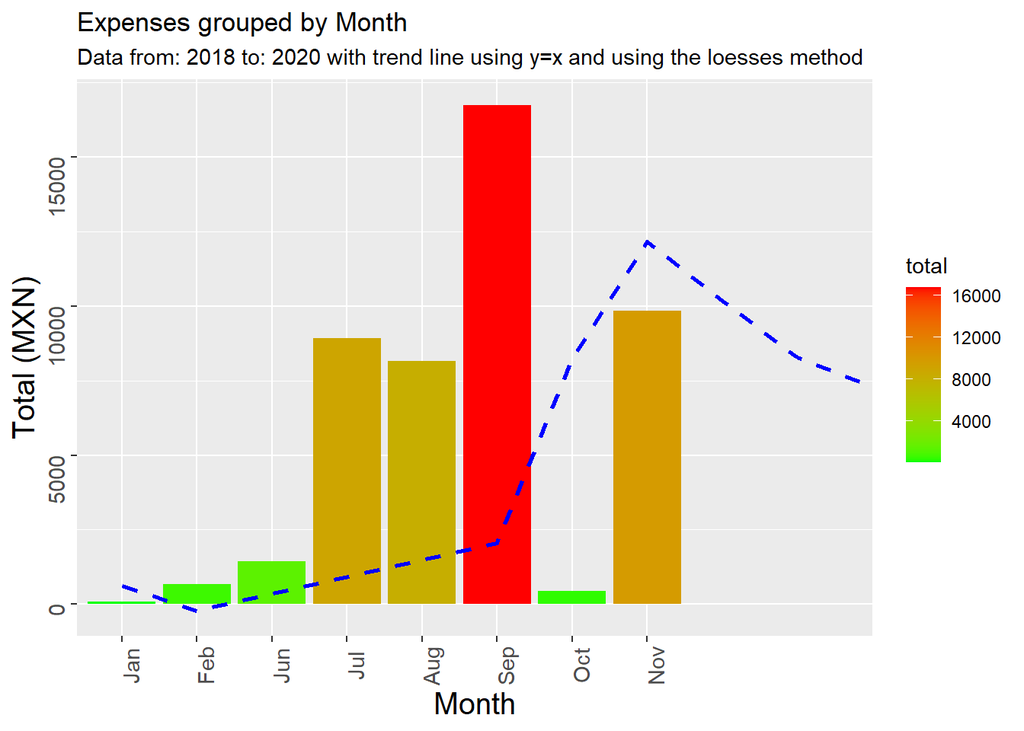

```r
ggplot(month_expense) +
  geom_col(mapping = aes(x=fct_inorder(month), y=total, fill=total)) +
  scale_fill_gradient(low="green", high="red", space='Lab') +
  geom_smooth(aes(x=numeric_months, y=total), method=loess, color="blue", formula=y ~ x, se=FALSE ,linetype = "dashed") +
  theme(axis.text.x = element_text(angle = 90, size = 11), axis.text.y = element_text(angle = 90, size = 11), axis.title.x = element_text(size = 15), axis.title.y = element_text(size = 15)) +
  labs(title = 'Expenses grouped by Month', subtitle = paste0("Data from: ", minyear, " to: ", maxyear, " with trend line using y=x and using the loesses method"), x = "Month", y = 'Total (MXN)')
```

Finally, plotting the year_expense data set. Using columns (bars) and filling each bar from green to red.

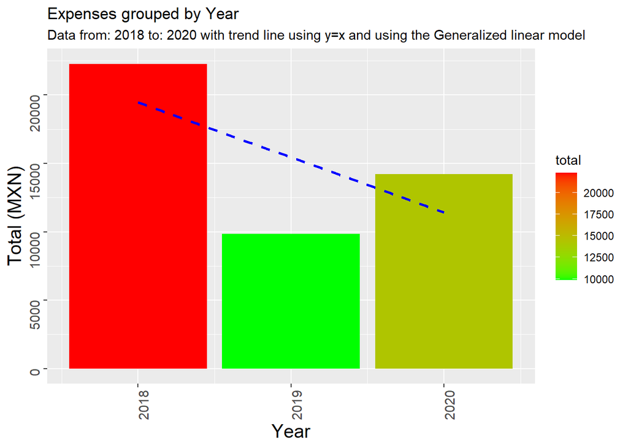

```r
ggplot(year_expense) + geom_col(mapping = aes(x=year, y=total, fill=total)) +
  scale_fill_gradient(low="green", high="red", space='Lab') +
  geom_smooth(aes(x=year, y=total), method=glm, color="blue", formula=y ~ x, se=FALSE, linetype = "dashed") +
  theme(axis.text.x = element_text(angle = 90, size = 11), axis.text.y = element_text(angle = 90, size = 11), axis.title.x = element_text(size = 15), axis.title.y = element_text(size = 15)) +
  labs(title = 'Expenses grouped by Year', subtitle = paste0("Data from: ", minyear, " to: ", maxyear, " with trend line using y=x and using the Generalized linear model"), x = "Year", y = 'Total (MXN)')
```

The trendline shows a excrement of money spent from 2018 to 2020, which predicts a decrease of expenses for 2021 and 2022. Of course, this data set only contains information from 3 years and the conclusions that can be generated from this information can be biased or inaccurate, and more data should require to be gathered.

## Conclusion

This R Script can help you have an understanding of your expenses and make some decisions to improve them based on available and raw data.